# Risk Factor Analysis

## Outcome Variable

**Outcome Variable:** stunted

## Predictor Variables

**Intervention Variable:** birthlen

**Adjustment Set:**

- arm
- sex
- W_mage
- meducyrs
- feducyrs
- W_mhtcm
- vagbrth
- single
- brthmon
- W_parity
- impsan
- delta_W_mage
- delta_meducyrs
- delta_feducyrs
- delta_W_mhtcm
- delta_vagbrth
- delta_single
- delta_brthmon
- delta_W_parity
- delta_impsan

## Stratifying Variables

The analysis was stratified on these variable(s):

- agecat
- studyid
- country

## Data Summary

| agecat | studyid | country | birthlen | stunted | n_cell | n |
| --- | --- | --- | --- | --- | --- | --- |
| Birth | ki0047075b-MAL-ED | BANGLADESH | >=0 | 0 | 39 | 257 |
| Birth | ki0047075b-MAL-ED | BANGLADESH | >=0 | 1 | 0 | 257 |
| Birth | ki0047075b-MAL-ED | BANGLADESH | <-3 | 0 | 0 | 257 |
| Birth | ki0047075b-MAL-ED | BANGLADESH | <-3 | 1 | 9 | 257 |
| Birth | ki0047075b-MAL-ED | BANGLADESH | [-3–2) | 0 | 0 | 257 |
| Birth | ki0047075b-MAL-ED | BANGLADESH | [-3–2) | 1 | 38 | 257 |
| Birth | ki0047075b-MAL-ED | BANGLADESH | [-2–1) | 0 | 83 | 257 |
| Birth | ki0047075b-MAL-ED | BANGLADESH | [-2–1) | 1 | 0 | 257 |
| Birth | ki0047075b-MAL-ED | BANGLADESH | [-1-0) | 0 | 88 | 257 |
| Birth | ki0047075b-MAL-ED | BANGLADESH | [-1-0) | 1 | 0 | 257 |
| 6 months | ki0047075b-MAL-ED | BANGLADESH | >=0 | 0 | 39 | 233 |
| 6 months | ki0047075b-MAL-ED | BANGLADESH | >=0 | 1 | 0 | 233 |
| 6 months | ki0047075b-MAL-ED | BANGLADESH | <-3 | 0 | 2 | 233 |
| 6 months | ki0047075b-MAL-ED | BANGLADESH | <-3 | 1 | 4 | 233 |
| 6 months | ki0047075b-MAL-ED | BANGLADESH | [-3–2) | 0 | 14 | 233 |
| 6 months | ki0047075b-MAL-ED | BANGLADESH | [-3–2) | 1 | 18 | 233 |
| 6 months | ki0047075b-MAL-ED | BANGLADESH | [-2–1) | 0 | 59 | 233 |
| 6 months | ki0047075b-MAL-ED | BANGLADESH | [-2–1) | 1 | 15 | 233 |
| 6 months | ki0047075b-MAL-ED | BANGLADESH | [-1-0) | 0 | 76 | 233 |
| 6 months | ki0047075b-MAL-ED | BANGLADESH | [-1-0) | 1 | 6 | 233 |
| 24 months | ki0047075b-MAL-ED | BANGLADESH | >=0 | 0 | 31 | 206 |
| 24 months | ki0047075b-MAL-ED | BANGLADESH | >=0 | 1 | 7 | 206 |
| 24 months | ki0047075b-MAL-ED | BANGLADESH | <-3 | 0 | 1 | 206 |
| 24 months | ki0047075b-MAL-ED | BANGLADESH | <-3 | 1 | 5 | 206 |
| 24 months | ki0047075b-MAL-ED | BANGLADESH | [-3–2) | 0 | 7 | 206 |
| 24 months | ki0047075b-MAL-ED | BANGLADESH | [-3–2) | 1 | 19 | 206 |
| 24 months | ki0047075b-MAL-ED | BANGLADESH | [-2–1) | 0 | 28 | 206 |
| 24 months | ki0047075b-MAL-ED | BANGLADESH | [-2–1) | 1 | 34 | 206 |
| 24 months | ki0047075b-MAL-ED | BANGLADESH | [-1-0) | 0 | 46 | 206 |
| 24 months | ki0047075b-MAL-ED | BANGLADESH | [-1-0) | 1 | 28 | 206 |

[output cut: 633 more lines]

The following strata were considered:

- agecat: 24 months, studyid: ki0047075b-MAL-ED, country: BANGLADESH
- agecat: 24 months, studyid: ki0047075b-MAL-ED, country: BRAZIL
- agecat: 24 months, studyid: ki0047075b-MAL-ED, country: INDIA
- agecat: 24 months, studyid: ki0047075b-MAL-ED, country: NEPAL
- agecat: 24 months, studyid: ki0047075b-MAL-ED, country: PERU
- agecat: 24 months, studyid: ki0047075b-MAL-ED, country: SOUTH AFRICA
- agecat: 24 months, studyid: ki0047075b-MAL-ED, country: TANZANIA, UNITED REPUBLIC OF
- agecat: 24 months, studyid: ki1000108-CMC-V-BCS-2002, country: INDIA
- agecat: 24 months, studyid: ki1000108-IRC, country: INDIA
- agecat: 24 months, studyid: ki1017093-NIH-Birth, country: BANGLADESH
- agecat: 24 months, studyid: ki1017093b-PROVIDE, country: BANGLADESH
- agecat: 24 months, studyid: ki1017093c-NIH-Crypto, country: BANGLADESH
- agecat: 24 months, studyid: ki1101329-Keneba, country: GAMBIA
- agecat: 24 months, studyid: ki1114097-CMIN, country: PERU
- agecat: 24 months, studyid: ki1114097-CONTENT, country: PERU
- agecat: 24 months, studyid: ki1119695-PROBIT, country: BELARUS
- agecat: 24 months, studyid: ki1126311-ZVITAMBO, country: ZIMBABWE
- agecat: 24 months, studyid: ki1135781-COHORTS, country: GUATEMALA
- agecat: 24 months, studyid: ki1135781-COHORTS, country: INDIA
- agecat: 24 months, studyid: ki1135781-COHORTS, country: PHILIPPINES
- agecat: 24 months, studyid: kiGH5241-JiVitA-3, country: BANGLADESH
- agecat: 24 months, studyid: kiGH5241-JiVitA-4, country: BANGLADESH
- agecat: 6 months, studyid: ki0047075b-MAL-ED, country: BANGLADESH
- agecat: 6 months, studyid: ki0047075b-MAL-ED, country: BRAZIL
- agecat: 6 months, studyid: ki0047075b-MAL-ED, country: INDIA
- agecat: 6 months, studyid: ki0047075b-MAL-ED, country: NEPAL
- agecat: 6 months, studyid: ki0047075b-MAL-ED, country: PERU
- agecat: 6 months, studyid: ki0047075b-MAL-ED, country: SOUTH AFRICA
- agecat: 6 months, studyid: ki0047075b-MAL-ED, country: TANZANIA, UNITED REPUBLIC OF
- agecat: 6 months, studyid: ki1000108-CMC-V-BCS-2002, country: INDIA
- agecat: 6 months, studyid: ki1000108-IRC, country: INDIA
- agecat: 6 months, studyid: ki1000109-EE, country: PAKISTAN
- agecat: 6 months, studyid: ki1000109-ResPak, country: PAKISTAN
- agecat: 6 months, studyid: ki1000304b-SAS-CompFeed, country: INDIA
- agecat: 6 months, studyid: ki1017093-NIH-Birth, country: BANGLADESH
- agecat: 6 months, studyid: ki1017093b-PROVIDE, country: BANGLADESH
- agecat: 6 months, studyid: ki1017093c-NIH-Crypto, country: BANGLADESH
- agecat: 6 months, studyid: ki1101329-Keneba, country: GAMBIA
- agecat: 6 months, studyid: ki1114097-CMIN, country: BRAZIL
- agecat: 6 months, studyid: ki1114097-CMIN, country: PERU
- agecat: 6 months, studyid: ki1114097-CONTENT, country: PERU
- agecat: 6 months, studyid: ki1119695-PROBIT, country: BELARUS
- agecat: 6 months, studyid: ki1126311-ZVITAMBO, country: ZIMBABWE
- agecat: 6 months, studyid: ki1135781-COHORTS, country: GUATEMALA
- agecat: 6 months, studyid: ki1135781-COHORTS, country: INDIA
- agecat: 6 months, studyid: ki1135781-COHORTS, country: PHILIPPINES
- agecat: 6 months, studyid: kiGH5241-JiVitA-3, country: BANGLADESH
- agecat: 6 months, studyid: kiGH5241-JiVitA-4, country: BANGLADESH
- agecat: Birth, studyid: ki0047075b-MAL-ED, country: BANGLADESH
- agecat: Birth, studyid: ki0047075b-MAL-ED, country: BRAZIL
- agecat: Birth, studyid: ki0047075b-MAL-ED, country: INDIA
- agecat: Birth, studyid: ki0047075b-MAL-ED, country: NEPAL
- agecat: Birth, studyid: ki0047075b-MAL-ED, country: PERU
- agecat: Birth, studyid: ki0047075b-MAL-ED, country: SOUTH AFRICA
- agecat: Birth, studyid: ki0047075b-MAL-ED, country: TANZANIA, UNITED REPUBLIC OF
- agecat: Birth, studyid: ki1000108-CMC-V-BCS-2002, country: INDIA
- agecat: Birth, studyid: ki1000108-IRC, country: INDIA
- agecat: Birth, studyid: ki1000109-EE, country: PAKISTAN
- agecat: Birth, studyid: ki1000109-ResPak, country: PAKISTAN
- agecat: Birth, studyid: ki1000304b-SAS-CompFeed, country: INDIA
- agecat: Birth, studyid: ki1017093-NIH-Birth, country: BANGLADESH
- agecat: Birth, studyid: ki1017093c-NIH-Crypto, country: BANGLADESH
- agecat: Birth, studyid: ki1101329-Keneba, country: GAMBIA
- agecat: Birth, studyid: ki1114097-CMIN, country: BANGLADESH
- agecat: Birth, studyid: ki1114097-CMIN, country: BRAZIL
- agecat: Birth, studyid: ki1114097-CMIN, country: PERU
- agecat: Birth, studyid: ki1114097-CONTENT, country: PERU
- agecat: Birth, studyid: ki1119695-PROBIT, country: BELARUS
- agecat: Birth, studyid: ki1126311-ZVITAMBO, country: ZIMBABWE
- agecat: Birth, studyid: ki1135781-COHORTS, country: GUATEMALA
- agecat: Birth, studyid: ki1135781-COHORTS, country: INDIA
- agecat: Birth, studyid: ki1135781-COHORTS, country: PHILIPPINES
- agecat: Birth, studyid: kiGH5241-JiVitA-3, country: BANGLADESH
- agecat: Birth, studyid: kiGH5241-JiVitA-4, country: BANGLADESH

### Dropped Strata

Some strata were dropped due to rare outcomes:

- agecat: Birth, studyid: ki0047075b-MAL-ED, country: BANGLADESH
- agecat: 6 months, studyid: ki0047075b-MAL-ED, country: BANGLADESH
- agecat: 24 months, studyid: ki0047075b-MAL-ED, country: BANGLADESH
- agecat: Birth, studyid: ki0047075b-MAL-ED, country: BRAZIL
- agecat: 6 months, studyid: ki0047075b-MAL-ED, country: BRAZIL
- agecat: 24 months, studyid: ki0047075b-MAL-ED, country: BRAZIL
- agecat: Birth, studyid: ki0047075b-MAL-ED, country: INDIA
- agecat: 6 months, studyid: ki0047075b-MAL-ED, country: INDIA
- agecat: 24 months, studyid: ki0047075b-MAL-ED, country: INDIA
- agecat: Birth, studyid: ki0047075b-MAL-ED, country: NEPAL
- agecat: 6 months, studyid: ki0047075b-MAL-ED, country: NEPAL
- agecat: 24 months, studyid: ki0047075b-MAL-ED, country: NEPAL
- agecat: Birth, studyid: ki0047075b-MAL-ED, country: PERU
- agecat: 6 months, studyid: ki0047075b-MAL-ED, country: PERU
- agecat: 24 months, studyid: ki0047075b-MAL-ED, country: PERU
- agecat: Birth, studyid: ki0047075b-MAL-ED, country: SOUTH AFRICA
- agecat: 6 months, studyid: ki0047075b-MAL-ED, country: SOUTH AFRICA
- agecat: 24 months, studyid: ki0047075b-MAL-ED, country: SOUTH AFRICA
- agecat: Birth, studyid: ki0047075b-MAL-ED, country: TANZANIA, UNITED REPUBLIC OF
- agecat: 6 months, studyid: ki0047075b-MAL-ED, country: TANZANIA, UNITED REPUBLIC OF
- agecat: 24 months, studyid: ki0047075b-MAL-ED, country: TANZANIA, UNITED REPUBLIC OF
- agecat: Birth, studyid: ki1000108-CMC-V-BCS-2002, country: INDIA
- agecat: 6 months, studyid: ki1000108-CMC-V-BCS-2002, country: INDIA
- agecat: 24 months, studyid: ki1000108-CMC-V-BCS-2002, country: INDIA
- agecat: Birth, studyid: ki1000108-IRC, country: INDIA
- agecat: Birth, studyid: ki1000109-EE, country: PAKISTAN
- agecat: 6 months, studyid: ki1000109-EE, country: PAKISTAN
- agecat: Birth, studyid: ki1000109-ResPak, country: PAKISTAN
- agecat: 6 months, studyid: ki1000109-ResPak, country: PAKISTAN
- agecat: Birth, studyid: ki1000304b-SAS-CompFeed, country: INDIA
- agecat: Birth, studyid: ki1017093-NIH-Birth, country: BANGLADESH
- agecat: 6 months, studyid: ki1017093-NIH-Birth, country: BANGLADESH
- agecat: 24 months, studyid: ki1017093-NIH-Birth, country: BANGLADESH
- agecat: 6 months, studyid: ki1017093b-PROVIDE, country: BANGLADESH
- agecat: 24 months, studyid: ki1017093b-PROVIDE, country: BANGLADESH
- agecat: Birth, studyid: ki1017093c-NIH-Crypto, country: BANGLADESH
- agecat: 6 months, studyid: ki1017093c-NIH-Crypto, country: BANGLADESH
- agecat: 24 months, studyid: ki1017093c-NIH-Crypto, country: BANGLADESH
- agecat: Birth, studyid: ki1101329-Keneba, country: GAMBIA
- agecat: Birth, studyid: ki1114097-CMIN, country: BANGLADESH
- agecat: Birth, studyid: ki1114097-CMIN, country: BRAZIL
- agecat: 6 months, studyid: ki1114097-CMIN, country: BRAZIL
- agecat: 24 months, studyid: ki1114097-CMIN, country: PERU
- agecat: Birth, studyid: ki1114097-CONTENT, country: PERU
- agecat: 6 months, studyid: ki1114097-CONTENT, country: PERU
- agecat: 24 months, studyid: ki1114097-CONTENT, country: PERU
- agecat: Birth, studyid: ki1119695-PROBIT, country: BELARUS
- agecat: 6 months, studyid: ki1119695-PROBIT, country: BELARUS
- agecat: 24 months, studyid: ki1119695-PROBIT, country: BELARUS
- agecat: Birth, studyid: ki1126311-ZVITAMBO, country: ZIMBABWE
- agecat: 24 months, studyid: ki1126311-ZVITAMBO, country: ZIMBABWE
- agecat: Birth, studyid: ki1135781-COHORTS, country: GUATEMALA
- agecat: 6 months, studyid: ki1135781-COHORTS, country: GUATEMALA
- agecat: 24 months, studyid: ki1135781-COHORTS, country: GUATEMALA
- agecat: Birth, studyid: ki1135781-COHORTS, country: INDIA
- agecat: Birth, studyid: ki1135781-COHORTS, country: PHILIPPINES
- agecat: 6 months, studyid: ki1135781-COHORTS, country: PHILIPPINES
- agecat: 24 months, studyid: ki1135781-COHORTS, country: PHILIPPINES
- agecat: Birth, studyid: kiGH5241-JiVitA-3, country: BANGLADESH
- agecat: Birth, studyid: kiGH5241-JiVitA-4, country: BANGLADESH

## Methods Detail

We’re interested in the causal parameters $E[Y_a]$ for all values of $a \in \mathcal{A}$. These parameters represent the mean outcome if, possibly contrary to fact, we intervened to set all units to have $A=a$. Under the randomization and positivity assumptions, these are identified by the statistical parameters $\psi_a=E_W[E_{Y|A,W}(Y|A=a,W)]$. In addition, we’re interested in the mean of $Y$, $E[Y]$ under no intervention (the observed mean). We will estimate these parameters by using SuperLearner to fit the relevant likelihood factors – $E_{Y|A,W}(Y|A=a,W)$ and $p(A=a|W)$, and then updating our likelihood fit using a joint TMLE.

For unadjusted analyses ($W=\{\}$), initial likelihoods were estimated using Lrnr_glm to estimate the simple $E(Y|A)$ and Lrnr_mean to estimate $p(A)$. For adjusted analyses, a small library containing Lrnr_glmnet, Lrnr_xgboost, and Lrnr_mean was used.

Having estimated these parameters, we will then use the delta method to estimate relative risks and attributable risks relative to a prespecified baseline level of $A$.

```
##          stunted
## birthlen  0
##   >=0     9
##   <-3     0
##   [-3--2) 0
##   [-2--1) 0
##   [-1-0)  0
##          stunted
## birthlen   0
##   >=0     10
##   <-3      0
##   [-3--2)  0
##   [-2--1)  0
##   [-1-0)   0
```

# Results Detail

## Results Plots

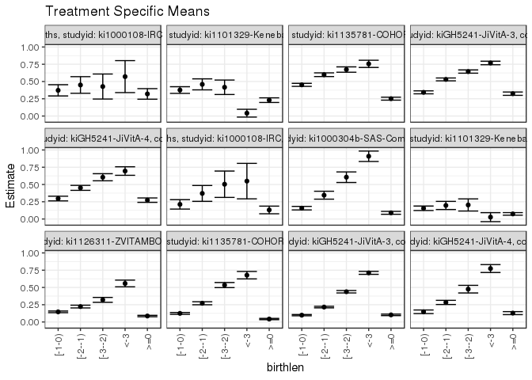

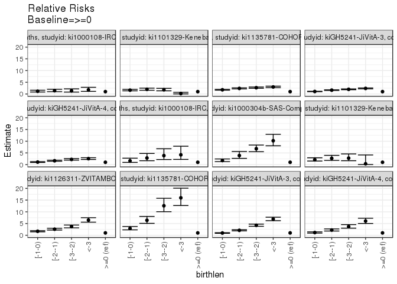

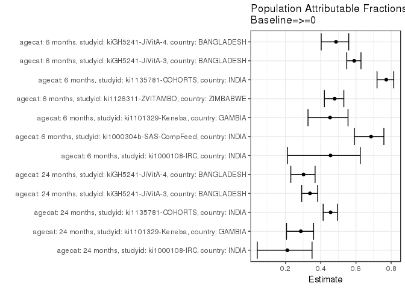

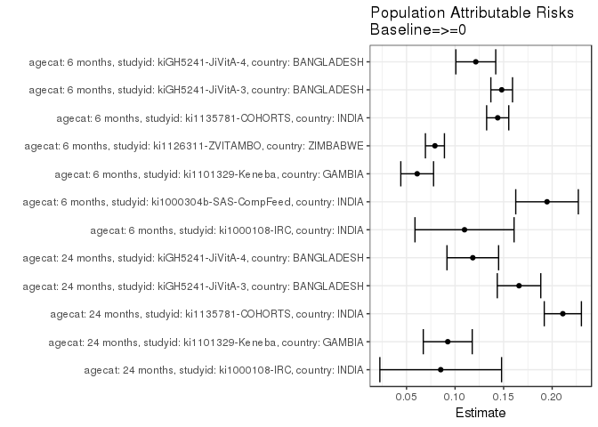

## Results Table

### Parameter: TSM

| agecat | studyid | country | intervention_level | baseline_level | estimate | ci_lower | ci_upper |
| --- | --- | --- | --- | --- | --- | --- | --- |
| 6 months | ki1000108-IRC | INDIA | >=0 | NA | 0.1311983 | 0.0756347 | 0.1867618 |
| 6 months | ki1000108-IRC | INDIA | <-3 | NA | 0.5489957 | 0.2920963 | 0.8058952 |
| 6 months | ki1000108-IRC | INDIA | [-3–2) | NA | 0.5036230 | 0.3127690 | 0.6944771 |
| 6 months | ki1000108-IRC | INDIA | [-2–1) | NA | 0.3707143 | 0.2557371 | 0.4856915 |
| 6 months | ki1000108-IRC | INDIA | [-1-0) | NA | 0.2120138 | 0.1439091 | 0.2801185 |
| 6 months | ki1000304b-SAS-CompFeed | INDIA | >=0 | NA | 0.0891612 | 0.0683892 | 0.1099332 |
| 6 months | ki1000304b-SAS-CompFeed | INDIA | <-3 | NA | 0.9087681 | 0.8334477 | 0.9840884 |
| 6 months | ki1000304b-SAS-CompFeed | INDIA | [-3–2) | NA | 0.6053897 | 0.5286739 | 0.6821054 |
| 6 months | ki1000304b-SAS-CompFeed | INDIA | [-2–1) | NA | 0.3448174 | 0.2876127 | 0.4020222 |
| 6 months | ki1000304b-SAS-CompFeed | INDIA | [-1-0) | NA | 0.1572342 | 0.1316790 | 0.1827894 |
| 6 months | ki1101329-Keneba | GAMBIA | >=0 | NA | 0.0736521 | 0.0549600 | 0.0923441 |
| 6 months | ki1101329-Keneba | GAMBIA | <-3 | NA | 0.0271051 | -0.0380253 | 0.0922354 |
| 6 months | ki1101329-Keneba | GAMBIA | [-3–2) | NA | 0.2033789 | 0.1153800 | 0.2913778 |
| 6 months | ki1101329-Keneba | GAMBIA | [-2–1) | NA | 0.1963830 | 0.1373597 | 0.2554062 |
| 6 months | ki1101329-Keneba | GAMBIA | [-1-0) | NA | 0.1553507 | 0.1229143 | 0.1877871 |
| 6 months | ki1126311-ZVITAMBO | ZIMBABWE | >=0 | NA | 0.0862560 | 0.0760820 | 0.0964300 |
| 6 months | ki1126311-ZVITAMBO | ZIMBABWE | <-3 | NA | 0.5576833 | 0.5091019 | 0.6062646 |
| 6 months | ki1126311-ZVITAMBO | ZIMBABWE | [-3–2) | NA | 0.3199817 | 0.2845304 | 0.3554330 |
| 6 months | ki1126311-ZVITAMBO | ZIMBABWE | [-2–1) | NA | 0.2229683 | 0.2030189 | 0.2429176 |
| 6 months | ki1126311-ZVITAMBO | ZIMBABWE | [-1-0) | NA | 0.1464742 | 0.1344051 | 0.1585432 |
| 6 months | ki1135781-COHORTS | INDIA | >=0 | NA | 0.0424384 | 0.0332952 | 0.0515816 |
| 6 months | ki1135781-COHORTS | INDIA | <-3 | NA | 0.6777140 | 0.6238773 | 0.7315507 |
| 6 months | ki1135781-COHORTS | INDIA | [-3–2) | NA | 0.5343263 | 0.4972876 | 0.5713650 |
| 6 months | ki1135781-COHORTS | INDIA | [-2–1) | NA | 0.2709069 | 0.2490260 | 0.2927879 |
| 6 months | ki1135781-COHORTS | INDIA | [-1-0) | NA | 0.1244770 | 0.1112334 | 0.1377205 |
| 6 months | kiGH5241-JiVitA-3 | BANGLADESH | >=0 | NA | 0.1027802 | 0.0920845 | 0.1134759 |
| 6 months | kiGH5241-JiVitA-3 | BANGLADESH | <-3 | NA | 0.7113709 | 0.6897841 | 0.7329576 |
| 6 months | kiGH5241-JiVitA-3 | BANGLADESH | [-3–2) | NA | 0.4378412 | 0.4201750 | 0.4555074 |
| 6 months | kiGH5241-JiVitA-3 | BANGLADESH | [-2–1) | NA | 0.2157951 | 0.2044275 | 0.2271627 |
| 6 months | kiGH5241-JiVitA-3 | BANGLADESH | [-1-0) | NA | 0.0984204 | 0.0895204 | 0.1073205 |
| 6 months | kiGH5241-JiVitA-4 | BANGLADESH | >=0 | NA | 0.1279653 | 0.1063938 | 0.1495369 |
| 6 months | kiGH5241-JiVitA-4 | BANGLADESH | <-3 | NA | 0.7737344 | 0.7165644 | 0.8309044 |
| 6 months | kiGH5241-JiVitA-4 | BANGLADESH | [-3–2) | NA | 0.4752429 | 0.4199042 | 0.5305816 |
| 6 months | kiGH5241-JiVitA-4 | BANGLADESH | [-2–1) | NA | 0.2832786 | 0.2530575 | 0.3134998 |
| 6 months | kiGH5241-JiVitA-4 | BANGLADESH | [-1-0) | NA | 0.1474358 | 0.1215188 | 0.1733528 |
| 24 months | ki1000108-IRC | INDIA | >=0 | NA | 0.3204712 | 0.2438289 | 0.3971135 |
| 24 months | ki1000108-IRC | INDIA | <-3 | NA | 0.5711031 | 0.3394277 | 0.8027785 |
| 24 months | ki1000108-IRC | INDIA | [-3–2) | NA | 0.4275354 | 0.2462999 | 0.6087708 |
| 24 months | ki1000108-IRC | INDIA | [-2–1) | NA | 0.4498954 | 0.3294520 | 0.5703388 |
| 24 months | ki1000108-IRC | INDIA | [-1-0) | NA | 0.3724942 | 0.2910320 | 0.4539564 |
| 24 months | ki1101329-Keneba | GAMBIA | >=0 | NA | 0.2301470 | 0.1966028 | 0.2636913 |
| 24 months | ki1101329-Keneba | GAMBIA | <-3 | NA | 0.0414367 | -0.0149613 | 0.0978347 |
| 24 months | ki1101329-Keneba | GAMBIA | [-3–2) | NA | 0.4169814 | 0.3122233 | 0.5217395 |
| 24 months | ki1101329-Keneba | GAMBIA | [-2–1) | NA | 0.4589770 | 0.3791364 | 0.5388177 |
| 24 months | ki1101329-Keneba | GAMBIA | [-1-0) | NA | 0.3765740 | 0.3282467 | 0.4249013 |
| 24 months | ki1135781-COHORTS | INDIA | >=0 | NA | 0.2517246 | 0.2303894 | 0.2730599 |
| 24 months | ki1135781-COHORTS | INDIA | <-3 | NA | 0.7561081 | 0.7039077 | 0.8083085 |
| 24 months | ki1135781-COHORTS | INDIA | [-3–2) | NA | 0.6733911 | 0.6345490 | 0.7122333 |
| 24 months | ki1135781-COHORTS | INDIA | [-2–1) | NA | 0.5984970 | 0.5717516 | 0.6252424 |
| 24 months | ki1135781-COHORTS | INDIA | [-1-0) | NA | 0.4517139 | 0.4295674 | 0.4738604 |
| 24 months | kiGH5241-JiVitA-3 | BANGLADESH | >=0 | NA | 0.3239662 | 0.2996532 | 0.3482791 |
| 24 months | kiGH5241-JiVitA-3 | BANGLADESH | <-3 | NA | 0.7685476 | 0.7430488 | 0.7940463 |
| 24 months | kiGH5241-JiVitA-3 | BANGLADESH | [-3–2) | NA | 0.6444233 | 0.6210594 | 0.6677872 |
| 24 months | kiGH5241-JiVitA-3 | BANGLADESH | [-2–1) | NA | 0.5307282 | 0.5102188 | 0.5512376 |
| 24 months | kiGH5241-JiVitA-3 | BANGLADESH | [-1-0) | NA | 0.3432601 | 0.3218128 | 0.3647073 |
| 24 months | kiGH5241-JiVitA-4 | BANGLADESH | >=0 | NA | 0.2730185 | 0.2412390 | 0.3047980 |
| 24 months | kiGH5241-JiVitA-4 | BANGLADESH | <-3 | NA | 0.6946786 | 0.6329823 | 0.7563749 |
| 24 months | kiGH5241-JiVitA-4 | BANGLADESH | [-3–2) | NA | 0.6049160 | 0.5534117 | 0.6564203 |
| 24 months | kiGH5241-JiVitA-4 | BANGLADESH | [-2–1) | NA | 0.4511150 | 0.4150801 | 0.4871499 |
| 24 months | kiGH5241-JiVitA-4 | BANGLADESH | [-1-0) | NA | 0.2960953 | 0.2620304 | 0.3301602 |

### Parameter: E(Y)

| agecat | studyid | country | intervention_level | baseline_level | estimate | ci_lower | ci_upper |
| --- | --- | --- | --- | --- | --- | --- | --- |
| 6 months | ki1000108-IRC | INDIA | NA | NA | 0.2409326 | 0.1982152 | 0.2836501 |
| 6 months | ki1000304b-SAS-CompFeed | INDIA | NA | NA | 0.2838759 | 0.2658427 | 0.3019090 |
| 6 months | ki1101329-Keneba | GAMBIA | NA | NA | 0.1346298 | 0.1163270 | 0.1529325 |
| 6 months | ki1126311-ZVITAMBO | ZIMBABWE | NA | NA | 0.1655037 | 0.1574443 | 0.1735632 |
| 6 months | ki1135781-COHORTS | INDIA | NA | NA | 0.1863384 | 0.1765934 | 0.1960835 |
| 6 months | kiGH5241-JiVitA-3 | BANGLADESH | NA | NA | 0.2507900 | 0.2426647 | 0.2589153 |
| 6 months | kiGH5241-JiVitA-4 | BANGLADESH | NA | NA | 0.2493116 | 0.2330908 | 0.2655325 |
| 24 months | ki1000108-IRC | INDIA | NA | NA | 0.4056848 | 0.3567004 | 0.4546691 |
| 24 months | ki1101329-Keneba | GAMBIA | NA | NA | 0.3226112 | 0.2944160 | 0.3508063 |
| 24 months | ki1135781-COHORTS | INDIA | NA | NA | 0.4627179 | 0.4485533 | 0.4768825 |
| 24 months | kiGH5241-JiVitA-3 | BANGLADESH | NA | NA | 0.4898420 | 0.4766223 | 0.5030617 |
| 24 months | kiGH5241-JiVitA-4 | BANGLADESH | NA | NA | 0.3912714 | 0.3725897 | 0.4099532 |

### Parameter: RR

| agecat | studyid | country | intervention_level | baseline_level | estimate | ci_lower | ci_upper |
| --- | --- | --- | --- | --- | --- | --- | --- |
| 6 months | ki1000108-IRC | INDIA | >=0 | >=0 | 1.0000000 | 1.0000000 | 1.0000000 |
| 6 months | ki1000108-IRC | INDIA | <-3 | >=0 | 4.1844742 | 2.2270020 | 7.8625092 |
| 6 months | ki1000108-IRC | INDIA | [-3–2) | >=0 | 3.8386410 | 2.1747621 | 6.7755293 |
| 6 months | ki1000108-IRC | INDIA | [-2–1) | >=0 | 2.8256037 | 1.6732232 | 4.7716506 |
| 6 months | ki1000108-IRC | INDIA | [-1-0) | >=0 | 1.6159800 | 0.9508188 | 2.7464659 |
| 6 months | ki1000304b-SAS-CompFeed | INDIA | >=0 | >=0 | 1.0000000 | 1.0000000 | 1.0000000 |
| 6 months | ki1000304b-SAS-CompFeed | INDIA | <-3 | >=0 | 10.1924201 | 8.0349666 | 12.9291673 |
| 6 months | ki1000304b-SAS-CompFeed | INDIA | [-3–2) | >=0 | 6.7898354 | 5.5205860 | 8.3509006 |
| 6 months | ki1000304b-SAS-CompFeed | INDIA | [-2–1) | >=0 | 3.8673501 | 2.6707853 | 5.5999996 |
| 6 months | ki1000304b-SAS-CompFeed | INDIA | [-1-0) | >=0 | 1.7634827 | 1.2810116 | 2.4276684 |
| 6 months | ki1101329-Keneba | GAMBIA | >=0 | >=0 | 1.0000000 | 1.0000000 | 1.0000000 |
| 6 months | ki1101329-Keneba | GAMBIA | <-3 | >=0 | 0.3680149 | 0.0328541 | 4.1223194 |
| 6 months | ki1101329-Keneba | GAMBIA | [-3–2) | >=0 | 2.7613463 | 1.6745334 | 4.5535274 |
| 6 months | ki1101329-Keneba | GAMBIA | [-2–1) | >=0 | 2.6663600 | 1.8013344 | 3.9467828 |
| 6 months | ki1101329-Keneba | GAMBIA | [-1-0) | >=0 | 2.1092508 | 1.5235363 | 2.9201397 |
| 6 months | ki1126311-ZVITAMBO | ZIMBABWE | >=0 | >=0 | 1.0000000 | 1.0000000 | 1.0000000 |
| 6 months | ki1126311-ZVITAMBO | ZIMBABWE | <-3 | >=0 | 6.4654428 | 5.5850649 | 7.4845954 |
| 6 months | ki1126311-ZVITAMBO | ZIMBABWE | [-3–2) | >=0 | 3.7096745 | 3.1567100 | 4.3595024 |
| 6 months | ki1126311-ZVITAMBO | ZIMBABWE | [-2–1) | >=0 | 2.5849593 | 2.2306016 | 2.9956109 |
| 6 months | ki1126311-ZVITAMBO | ZIMBABWE | [-1-0) | >=0 | 1.6981332 | 1.4718099 | 1.9592587 |
| 6 months | ki1135781-COHORTS | INDIA | >=0 | >=0 | 1.0000000 | 1.0000000 | 1.0000000 |
| 6 months | ki1135781-COHORTS | INDIA | <-3 | >=0 | 15.9693589 | 12.6949457 | 20.0883428 |
| 6 months | ki1135781-COHORTS | INDIA | [-3–2) | >=0 | 12.5906329 | 10.0427782 | 15.7848788 |
| 6 months | ki1135781-COHORTS | INDIA | [-2–1) | >=0 | 6.3835336 | 5.0731419 | 8.0323992 |
| 6 months | ki1135781-COHORTS | INDIA | [-1-0) | >=0 | 2.9331216 | 2.3077063 | 3.7280317 |
| 6 months | kiGH5241-JiVitA-3 | BANGLADESH | >=0 | >=0 | 1.0000000 | 1.0000000 | 1.0000000 |
| 6 months | kiGH5241-JiVitA-3 | BANGLADESH | <-3 | >=0 | 6.9212836 | 6.2159206 | 7.7066889 |
| 6 months | kiGH5241-JiVitA-3 | BANGLADESH | [-3–2) | >=0 | 4.2599764 | 3.8198484 | 4.7508166 |
| 6 months | kiGH5241-JiVitA-3 | BANGLADESH | [-2–1) | >=0 | 2.0995787 | 1.8726603 | 2.3539938 |
| 6 months | kiGH5241-JiVitA-3 | BANGLADESH | [-1-0) | >=0 | 0.9575818 | 0.8363281 | 1.0964154 |
| 6 months | kiGH5241-JiVitA-4 | BANGLADESH | >=0 | >=0 | 1.0000000 | 1.0000000 | 1.0000000 |
| 6 months | kiGH5241-JiVitA-4 | BANGLADESH | <-3 | >=0 | 6.0464387 | 5.0342506 | 7.2621377 |
| 6 months | kiGH5241-JiVitA-4 | BANGLADESH | [-3–2) | >=0 | 3.7138417 | 3.0336411 | 4.5465564 |
| 6 months | kiGH5241-JiVitA-4 | BANGLADESH | [-2–1) | >=0 | 2.2137144 | 1.8078843 | 2.7106444 |
| 6 months | kiGH5241-JiVitA-4 | BANGLADESH | [-1-0) | >=0 | 1.1521541 | 0.9057182 | 1.4656426 |
| 24 months | ki1000108-IRC | INDIA | >=0 | >=0 | 1.0000000 | 1.0000000 | 1.0000000 |
| 24 months | ki1000108-IRC | INDIA | <-3 | >=0 | 1.7820733 | 1.1128163 | 2.8538270 |
| 24 months | ki1000108-IRC | INDIA | [-3–2) | >=0 | 1.3340837 | 0.8200476 | 2.1703367 |
| 24 months | ki1000108-IRC | INDIA | [-2–1) | >=0 | 1.4038562 | 0.9805500 | 2.0099048 |
| 24 months | ki1000108-IRC | INDIA | [-1-0) | >=0 | 1.1623330 | 0.8400551 | 1.6082492 |
| 24 months | ki1101329-Keneba | GAMBIA | >=0 | >=0 | 1.0000000 | 1.0000000 | 1.0000000 |
| 24 months | ki1101329-Keneba | GAMBIA | <-3 | >=0 | 0.1800445 | 0.0458458 | 0.7070665 |
| 24 months | ki1101329-Keneba | GAMBIA | [-3–2) | >=0 | 1.8118042 | 1.3582632 | 2.4167882 |
| 24 months | ki1101329-Keneba | GAMBIA | [-2–1) | >=0 | 1.9942772 | 1.5915364 | 2.4989322 |
| 24 months | ki1101329-Keneba | GAMBIA | [-1-0) | >=0 | 1.6362321 | 1.3517387 | 1.9806015 |
| 24 months | ki1135781-COHORTS | INDIA | >=0 | >=0 | 1.0000000 | 1.0000000 | 1.0000000 |
| 24 months | ki1135781-COHORTS | INDIA | <-3 | >=0 | 3.0037111 | 2.6941640 | 3.3488237 |
| 24 months | ki1135781-COHORTS | INDIA | [-3–2) | >=0 | 2.6751100 | 2.4164932 | 2.9614044 |
| 24 months | ki1135781-COHORTS | INDIA | [-2–1) | >=0 | 2.3775862 | 2.1623484 | 2.6142485 |
| 24 months | ki1135781-COHORTS | INDIA | [-1-0) | >=0 | 1.7944763 | 1.6292766 | 1.9764264 |
| 24 months | kiGH5241-JiVitA-3 | BANGLADESH | >=0 | >=0 | 1.0000000 | 1.0000000 | 1.0000000 |
| 24 months | kiGH5241-JiVitA-3 | BANGLADESH | <-3 | >=0 | 2.3723082 | 2.1854945 | 2.5750905 |
| 24 months | kiGH5241-JiVitA-3 | BANGLADESH | [-3–2) | >=0 | 1.9891687 | 1.8335813 | 2.1579583 |
| 24 months | kiGH5241-JiVitA-3 | BANGLADESH | [-2–1) | >=0 | 1.6382211 | 1.5096864 | 1.7776993 |
| 24 months | kiGH5241-JiVitA-3 | BANGLADESH | [-1-0) | >=0 | 1.0595553 | 0.9629421 | 1.1658619 |
| 24 months | kiGH5241-JiVitA-4 | BANGLADESH | >=0 | >=0 | 1.0000000 | 1.0000000 | 1.0000000 |
| 24 months | kiGH5241-JiVitA-4 | BANGLADESH | <-3 | >=0 | 2.5444379 | 2.1932305 | 2.9518849 |
| 24 months | kiGH5241-JiVitA-4 | BANGLADESH | [-3–2) | >=0 | 2.2156595 | 1.9257134 | 2.5492615 |
| 24 months | kiGH5241-JiVitA-4 | BANGLADESH | [-2–1) | >=0 | 1.6523240 | 1.4353231 | 1.9021323 |
| 24 months | kiGH5241-JiVitA-4 | BANGLADESH | [-1-0) | >=0 | 1.0845248 | 0.9220448 | 1.2756365 |

### Parameter: PAR

| agecat | studyid | country | intervention_level | baseline_level | estimate | ci_lower | ci_upper |
| --- | --- | --- | --- | --- | --- | --- | --- |
| 6 months | ki1000108-IRC | INDIA | >=0 | NA | 0.1097344 | 0.0587053 | 0.1607635 |
| 6 months | ki1000304b-SAS-CompFeed | INDIA | >=0 | NA | 0.1947147 | 0.1624933 | 0.2269361 |
| 6 months | ki1101329-Keneba | GAMBIA | >=0 | NA | 0.0609777 | 0.0441055 | 0.0778498 |
| 6 months | ki1126311-ZVITAMBO | ZIMBABWE | >=0 | NA | 0.0792477 | 0.0694504 | 0.0890451 |
| 6 months | ki1135781-COHORTS | INDIA | >=0 | NA | 0.1439000 | 0.1325073 | 0.1552928 |
| 6 months | kiGH5241-JiVitA-3 | BANGLADESH | >=0 | NA | 0.1480098 | 0.1368556 | 0.1591640 |
| 6 months | kiGH5241-JiVitA-4 | BANGLADESH | >=0 | NA | 0.1213463 | 0.1008034 | 0.1418893 |
| 24 months | ki1000108-IRC | INDIA | >=0 | NA | 0.0852136 | 0.0225292 | 0.1478979 |
| 24 months | ki1101329-Keneba | GAMBIA | >=0 | NA | 0.0924641 | 0.0672556 | 0.1176726 |
| 24 months | ki1135781-COHORTS | INDIA | >=0 | NA | 0.2109933 | 0.1918566 | 0.2301299 |
| 24 months | kiGH5241-JiVitA-3 | BANGLADESH | >=0 | NA | 0.1658758 | 0.1434771 | 0.1882746 |
| 24 months | kiGH5241-JiVitA-4 | BANGLADESH | >=0 | NA | 0.1182530 | 0.0916637 | 0.1448422 |

### Parameter: PAF

| agecat | studyid | country | intervention_level | baseline_level | estimate | ci_lower | ci_upper |
| --- | --- | --- | --- | --- | --- | --- | --- |
| 6 months | ki1000108-IRC | INDIA | >=0 | NA | 0.4554567 | 0.2107137 | 0.6243094 |
| 6 months | ki1000304b-SAS-CompFeed | INDIA | >=0 | NA | 0.6859149 | 0.5912234 | 0.7586715 |
| 6 months | ki1101329-Keneba | GAMBIA | >=0 | NA | 0.4529287 | 0.3275500 | 0.5549305 |
| 6 months | ki1126311-ZVITAMBO | ZIMBABWE | >=0 | NA | 0.4788274 | 0.4206286 | 0.5311801 |
| 6 months | ki1135781-COHORTS | INDIA | >=0 | NA | 0.7722510 | 0.7197807 | 0.8148963 |
| 6 months | kiGH5241-JiVitA-3 | BANGLADESH | >=0 | NA | 0.5901743 | 0.5477421 | 0.6286253 |
| 6 months | kiGH5241-JiVitA-4 | BANGLADESH | >=0 | NA | 0.4867255 | 0.4025822 | 0.5590176 |
| 24 months | ki1000108-IRC | INDIA | >=0 | NA | 0.2100488 | 0.0391396 | 0.3505582 |
| 24 months | ki1101329-Keneba | GAMBIA | >=0 | NA | 0.2866117 | 0.2055659 | 0.3593893 |
| 24 months | ki1135781-COHORTS | INDIA | >=0 | NA | 0.4559868 | 0.4135807 | 0.4953264 |
| 24 months | kiGH5241-JiVitA-3 | BANGLADESH | >=0 | NA | 0.3386313 | 0.2917215 | 0.3824342 |
| 24 months | kiGH5241-JiVitA-4 | BANGLADESH | >=0 | NA | 0.3022274 | 0.2299061 | 0.3677568 |